# Análise da Bay Area Bike Share

## Introdução

[Bay Area Bike Share](http://www.bayareabikeshare.com/) é uma empresa que oferece aluguel de bicicletas on-demand para clientes em San Francisco, Redwood City, Palo Alto, Mountain View e San Jose. Os usuários podem desbloquear bicicletas de uma variedade de estações em cada cidade, e devolvê-las em qualquer estação dentro da mesma cidade. Os usuários pagam o serviço por meio de assinatura anual ou pela compra de passes de 3 dias ou 24 horas. Os usuários podem fazer um número ilimitado de viagens. Viagens com menos de trinta minutos de duração não têm custo adicional; Viagens mais longas incorrem em taxas de horas extras.

O projeto, visa colocar no lugar de um analista de dados realizando uma análise exploratória sobre os dados. Pondo em prática dois passos importantes: limpeza de dados e análise exploratória.

## Data Wrangling (Limpeza de Dados)

```python
# Importa todas as bibliotecas necessárias
%matplotlib inline
import csv
from datetime import datetime
import numpy as np
import pandas as pd
from babs_datacheck import question_3
from babs_visualizations import usage_stats, usage_plot
from IPython.display import display
import matplotlib.pyplot as plt
```

```python
# definição dos arquivos
file_in  = '201402_trip_data.csv'
file_out = '201309_trip_data.csv'

with open(file_out, 'w') as f_out, open(file_in, 'r') as f_in:
    # configura o leitor de csv
    in_reader = csv.reader(f_in)
    out_writer = csv.writer(f_out)

    # escreve os dados no arquivo de saída até que a data limite seja atingida
    while True:
        datarow = next(in_reader)
        # data de início de das viagens na terceira coluna no formato 'm/d/yyyy HH:MM'
        if datarow[2][:9] == '10/1/2013':
            break
        out_writer.writerow(datarow)
```

### Condensando os Dados de Viagem

```python
sample_data = pd.read_csv('201309_trip_data.csv')

sample_data.head()
```

|  | Trip ID | Duration | Start Date | Start Station | Start Terminal | End Date | End Station | End Terminal | Bike # | Subscription Type | Zip Code |
| --- | --- | --- | --- | --- | --- | --- | --- | --- | --- | --- | --- |
| 0 | 4576 | 63 | 8/29/2013 14:13 | South Van Ness at Market | 66 | 8/29/2013 14:14 | South Van Ness at Market | 66 | 520 | Subscriber | 94127 |
| 1 | 4607 | 70 | 8/29/2013 14:42 | San Jose City Hall | 10 | 8/29/2013 14:43 | San Jose City Hall | 10 | 661 | Subscriber | 95138 |
| 2 | 4130 | 71 | 8/29/2013 10:16 | Mountain View City Hall | 27 | 8/29/2013 10:17 | Mountain View City Hall | 27 | 48 | Subscriber | 97214 |
| 3 | 4251 | 77 | 8/29/2013 11:29 | San Jose City Hall | 10 | 8/29/2013 11:30 | San Jose City Hall | 10 | 26 | Subscriber | 95060 |
| 4 | 4299 | 83 | 8/29/2013 12:02 | South Van Ness at Market | 66 | 8/29/2013 12:04 | Market at 10th | 67 | 319 | Subscriber | 94103 |

```python
# Mostra as primeiras linhas do arquivo de dados das estações
station_info = pd.read_csv('201402_station_data.csv')
station_info.head()
```

|  | station_id | name | lat | long | dockcount | landmark | installation |
| --- | --- | --- | --- | --- | --- | --- | --- |
| 0 | 2 | San Jose Diridon Caltrain Station | 37.329732 | -121.901782 | 27 | San Jose | 8/6/2013 |
| 1 | 3 | San Jose Civic Center | 37.330698 | -121.888979 | 15 | San Jose | 8/5/2013 |
| 2 | 4 | Santa Clara at Almaden | 37.333988 | -121.894902 | 11 | San Jose | 8/6/2013 |
| 3 | 5 | Adobe on Almaden | 37.331415 | -121.893200 | 19 | San Jose | 8/5/2013 |
| 4 | 6 | San Pedro Square | 37.336721 | -121.894074 | 15 | San Jose | 8/7/2013 |

```python
def create_station_mapping(station_data):
    """
    Cria um mapeamento (tambémm conhecido como de-para) entre a estação
    e a cidade
    """
    station_map = {}
    for data_file in station_data:
        with open(data_file, 'r') as f_in:

            weather_reader = csv.DictReader(f_in)

            for row in weather_reader:
                station_map[row['station_id']] = row['landmark']
    return station_map
```

```python
def summarise_data(trip_in, station_data, trip_out):

    # gera o dicionário de mapeamento entre estações e cidades
    station_map = create_station_mapping(station_data)

    with open(trip_out, 'w') as f_out:
        # configura o objeto de escrita de csv
        out_colnames = ['duration', 'start_date', 'start_year',
                        'start_month', 'start_hour', 'weekday',
                        'start_city', 'end_city', 'subscription_type']
        trip_writer = csv.DictWriter(f_out, fieldnames = out_colnames)
        trip_writer.writeheader()

        for data_file in trip_in:
            with open(data_file, 'r') as f_in:
                # configura o leitor do csv
                trip_reader = csv.DictReader(f_in)

                # processa cada linha lendo uma a uma
                for row in trip_reader:
                    new_point = {}

                    # converte a duração de segundos para minutos.
                    new_point['duration'] = int(row['Duration'])/60.0

                    # reformate strings com datas para múltiplas colunas
                    trip_date = datetime.strptime(row['Start Date'], '%m/%d/%Y %H:%M')
                    new_point['start_date']  = trip_date.day
                    new_point['start_year']  = trip_date.year
                    new_point['start_month'] = trip_date.month
                    new_point['start_hour']  = trip_date.hour
                    new_point['weekday']     = trip_date.strftime("%A")

                    # mapeia o terminal de inicio e fim com o a cidade de inicio e fim
                    new_point['start_city'] = station_map[row['Start Terminal']]
                    new_point['end_city']= station_map[row['End Terminal']]

                    if 'Subscription Type' in row:
                        new_point['subscription_type'] = row['Subscription Type']
                    else:
                        new_point['subscription_type'] = row['Subscriber Type']

                    # escreve a informação processada para o arquivo de saída.
                    trip_writer.writerow(new_point)
```

## Verificando as contagem de dados

```python
# processe os dados usando a função criada acima
station_data = ['201402_station_data.csv']
trip_in = ['201309_trip_data.csv']
trip_out = '201309_trip_summary.csv'
summarise_data(trip_in, station_data, trip_out)
```

```python
# Carregue os dados novamente mostrando os dados
sample_data = pd.read_csv(trip_out)
display(sample_data.head())
```

|  | duration | start_date | start_year | start_month | start_hour | weekday | start_city | end_city | subscription_type |
| --- | --- | --- | --- | --- | --- | --- | --- | --- | --- |
| 0 | 1.050000 | 29 | 2013 | 8 | 14 | Thursday | San Francisco | San Francisco | Subscriber |
| 1 | 1.166667 | 29 | 2013 | 8 | 14 | Thursday | San Jose | San Jose | Subscriber |
| 2 | 1.183333 | 29 | 2013 | 8 | 10 | Thursday | Mountain View | Mountain View | Subscriber |
| 3 | 1.283333 | 29 | 2013 | 8 | 11 | Thursday | San Jose | San Jose | Subscriber |
| 4 | 1.383333 | 29 | 2013 | 8 | 12 | Thursday | San Francisco | San Francisco | Subscriber |

```python
question_3(sample_data)
```

```
Todas as contagens estão como esperadas.
```

## Análise Exploratória de Dados

```python
trip_data = pd.read_csv('201309_trip_summary.csv')
trip_data.head()
```

|  | duration | start_date | start_year | start_month | start_hour | weekday | start_city | end_city | subscription_type |
| --- | --- | --- | --- | --- | --- | --- | --- | --- | --- |
| 0 | 1.050000 | 29 | 2013 | 8 | 14 | Thursday | San Francisco | San Francisco | Subscriber |
| 1 | 1.166667 | 29 | 2013 | 8 | 14 | Thursday | San Jose | San Jose | Subscriber |
| 2 | 1.183333 | 29 | 2013 | 8 | 10 | Thursday | Mountain View | Mountain View | Subscriber |
| 3 | 1.283333 | 29 | 2013 | 8 | 11 | Thursday | San Jose | San Jose | Subscriber |
| 4 | 1.383333 | 29 | 2013 | 8 | 12 | Thursday | San Francisco | San Francisco | Subscriber |

```python
print('Existem {:d} pontos no conjunto de dados'.format(trip_data.shape[0]))
print('A duração média das viagens foi de {:.2f} minutos'.format(trip_data['duration'].mean()))
print('A mediana das durações das viagens foi de {:.2f} minutos'.format(trip_data['duration'].median()))


duration_qtiles = trip_data['duration'].quantile([.25, .5, .75]).as_matrix()

print('25% das viagens foram mais curtas do que {:.2f} minutos'.format(duration_qtiles[0]))
print('25% das viagens foram mais compridas do que {:.2f} minutos'.format(duration_qtiles[2]))
```

```
Existem 27345 pontos no conjunto de dados
A duração média das viagens foi de 27.60 minutos
A mediana das durações das viagens foi de 10.72 minutos
25% das viagens foram mais curtas do que 6.82 minutos
25% das viagens foram mais compridas do que 17.28 minutos
```

```python
usage_stats(trip_data)
```

```
Existem 27345 pontos no conjunto de dados
A duração média das viagens foi de 27.60 minutos
A mediana das durações das viagens foi de 10.72 minutos
25% das viagens foram mais curtas do que 6.82 minutos
25% das viagens foram mais compridas do que 17.28 minutos
```

```
array([ 6.81666667, 10.71666667, 17.28333333])
```

[figure not shown]

```python
# TODO: plote um gráfico de barras que mostre quantidade de viagens por subscription_type

subscription_type = trip_data.groupby('subscription_type')['subscription_type'].count()
plt.bar([1, 2], subscription_type, tick_label=['Customer', 'Subscriber'], color=['#ef6461', '#e4b363'])
plt.title('Quantidade de viagens X Tipo de Subscrição')
plt.ylabel('Quantidade de Viagens')
plt.xlabel('Tipo de Subscrição')
plt.show()
```

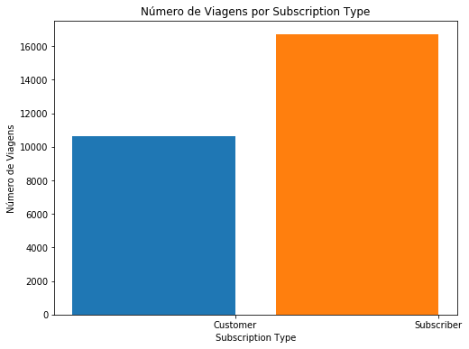

```python
usage_plot(trip_data, 'subscription_type')
```

```python
# Gráfico baseado nas durações
```

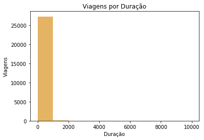

```python
trip_data['duration'].plot(kind='hist', color = ['#e4b363'])

plt.title('Viagens por Duração')
plt.ylabel('Viagens')
plt.xlabel('Duração')
plt.show()
```

```python
# Gráfico de barras para os dados com duração inferior a 60 minutos.
```

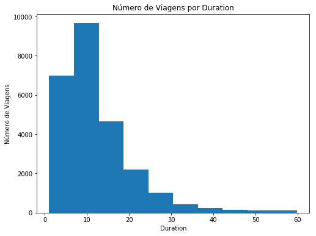

```python
usage_plot(trip_data, 'duration', ['duration < 60'])
```

[figure not shown]

```python
#usage_plot(trip_data, 'duration', ['duration < 60'], boundary = 0, bin_width = 5)

bins = np.arange(0, 60, 5)
search = trip_data.loc[trip_data['duration'] <= 60]
search['duration'].plot(kind='hist', bins = bins, color = ['#e4b363'])

plt.title('Viagens por Duração')
plt.ylabel('Viagens')
plt.xlabel('Duração')
plt.show()
```

Pequenos ajustes como este podem ser pequenos mas fazem toda a diferença na entrega de um trabalho de qualidade e com atenção aos detalhes.

Entre o intervalo de 5 a 10 há um maior número de viagens registradas

A cidade de San Francisco tem a maior quantidade de viagens com 8129 viagens registradas.

```python
index = (search['duration'] >= 5) & (search['duration'] <= 10)
search[index].groupby( ['start_city', 'end_city']).size()
```

```
start_city     end_city
Mountain View  Mountain View     105
Palo Alto      Palo Alto          50
Redwood City   Redwood City       66
San Francisco  San Francisco    8129
San Jose       San Jose          675
dtype: int64
```

```python
station_data = ['201402_station_data.csv',
                '201408_station_data.csv',
                '201508_station_data.csv' ]
trip_in = ['201402_trip_data.csv',
           '201408_trip_data.csv',
           '201508_trip_data.csv' ]
trip_out = 'babs_y1_y2_summary.csv'

# Esta função irá ler as informações das estações e das viagens
# e escreverá um arquivo processado com o nome trip_out
summarise_data(trip_in, station_data, trip_out)
```

```python
trip_data = pd.read_csv('babs_y1_y2_summary.csv')
display(trip_data.head())
```

|  | duration | start_date | start_year | start_month | start_hour | weekday | start_city | end_city | subscription_type |
| --- | --- | --- | --- | --- | --- | --- | --- | --- | --- |
| 0 | 1.050000 | 29 | 2013 | 8 | 14 | Thursday | San Francisco | San Francisco | Subscriber |
| 1 | 1.166667 | 29 | 2013 | 8 | 14 | Thursday | San Jose | San Jose | Subscriber |
| 2 | 1.183333 | 29 | 2013 | 8 | 10 | Thursday | Mountain View | Mountain View | Subscriber |
| 3 | 1.283333 | 29 | 2013 | 8 | 11 | Thursday | San Jose | San Jose | Subscriber |
| 4 | 1.383333 | 29 | 2013 | 8 | 12 | Thursday | San Francisco | San Francisco | Subscriber |

```python
#Estatistica
usage_stats(trip_data)
```

```
Existem 669959 pontos no conjunto de dados
A duração média das viagens foi de 18.47 minutos
A mediana das durações das viagens foi de 8.62 minutos
25% das viagens foram mais curtas do que 5.73 minutos
25% das viagens foram mais compridas do que 12.58 minutos
```

```
array([ 5.73333333,  8.61666667, 12.58333333])
```

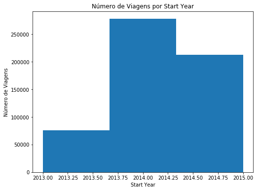

```python
#Explorando alguns gráficos

usage_plot(trip_data, 'start_year', ["subscription_type == 'Subscriber'"], n_bins = 3)
```

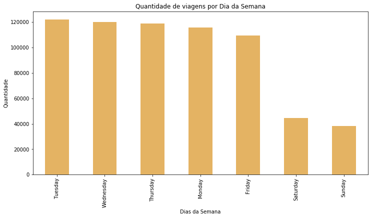

```python
# Gráfico final 1
#weekdays = ["Monday", "Tuesday", "Wednesday", "Thursday", "Friday", "Saturday", "Sunday"]
#name_dict = {i:day for i, day in enumerate(weekdays)}
#trip_data.groupby("weekday").count()["duration"].rename(name_dict).plot(kind="bar")
#plt.show()
#Através da dica para colcoar nome nos meses, refiz o gráfico final para mostrar o uso de viagens por dia da semana

trip_data['weekday'].value_counts().plot(kind = 'bar' , color = ['#e4b363'], figsize = (12, 6));

plt.title('Quantidade de viagens por Dia da Semana')
plt.xlabel('Dias da Semana')
plt.ylabel('Quantidade')
plt.show()
```

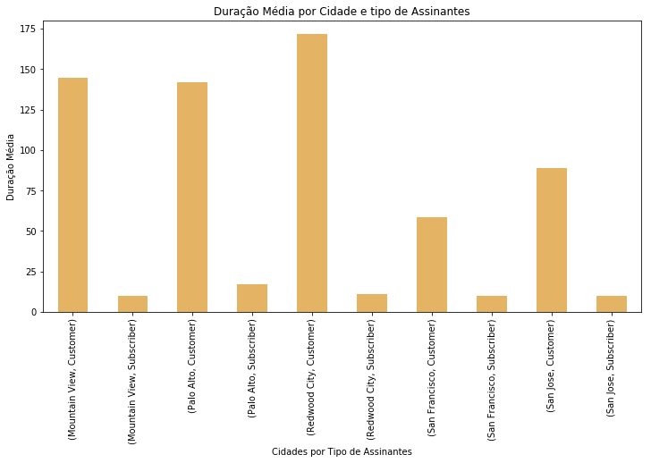

```python
# Gráfico Final 2
search  = trip_data.groupby(['start_city','subscription_type'])['duration'].mean()
search.head(3)
search.plot(kind='bar', color=['#e4b363'], figsize=(12,6))

plt.title('Duração Média por Cidade e tipo de Assinantes')
plt.xlabel('Cidades por Tipo de Assinantes')
plt.ylabel('Duração Média')
plt.show()
```